# Health Modelling HUN

Gabor Simon gabor.simon75@gmail.com

December 31, 2017

## About

This application lets you fit linear models between various health-affecting predictors and two possible outcomes.

**NOTE:** As any health-related change takes time from cause to effect, it makes very little sense to relate predictors and outcomes from the same year, so the goal here is rather to demonstrate the technology than to explore new correlations.

The source GitHub repository is accessible [here](https://github.com/gsimon75/HealthModellingHUN), the online viewable HTML page [here](https://gsimon75.github.io/HealthModellingHUN/).

## The concept

You may choose from two outcomes: the **birth** and the **death rate** (per 1000 people).

The predictors may be any arbitrary subset of some consumption- and healthcare-related statistics:

The average consumption of certain foods in the given year: **meat**, **dairy** products, **flour** and rice, **sugar**, **potato** (kg/capita), **eggs** (piece/capita) and the average **energy** content (kJ/day/capita).

The remaining predictors are healthcare-related: number of **doctors** and **hospital beds** (per 10000 people).

When at least one predictor is selected, the predicted values and the 95% confidence interval is plotted, and the results of the fitting and the linear coefficients are printed.

When at least two predictors are selected, their Variance Inflation Factors are also printed.

**NOTE:** As long as no predictors are selected, there is nothing to display…

## The data

The data is annual statistics between 1960-2015, and the raw correlations are these:

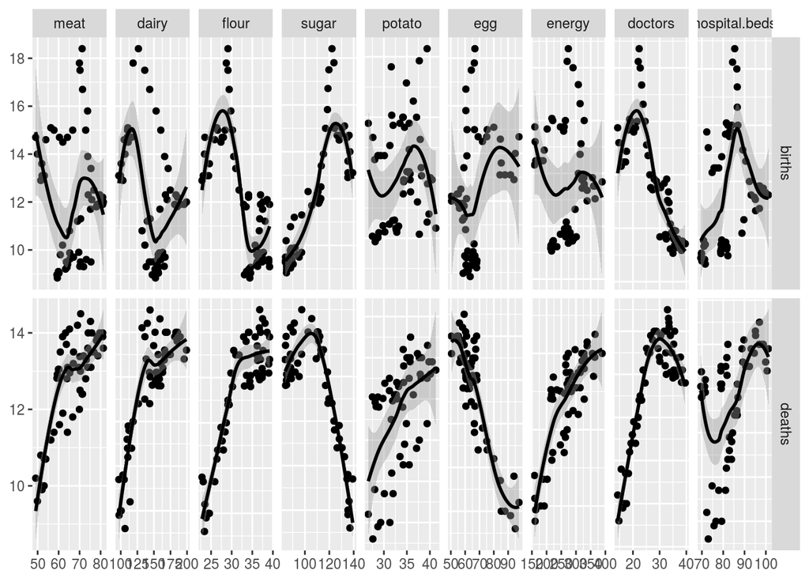

```r
ggduo(hstat, columnsY=c("births", "deaths"), columnsX=c("meat", "dairy", "flour", "sugar", "potato", "egg", "energy", "doctors", "hospital.beds"))
```

All sources are freely available from the [Hungarian Central Statistics Office](http://www.ksh.hu):

- [Health Statistics](http://www.ksh.hu/docs/hun/xstadat/xstadat_hosszu/h_wdsd001a.html), [data](http://www.ksh.hu/docs/hun/xstadat/xstadat_hosszu/xls/h2_2.xls), [databook](http://www.ksh.hu/apps/meta.objektum?p_lang=EN&p_menu_id=110&p_ot_id=100&p_obj_id=WNT)
- [Consumption per Capita](http://www.ksh.hu/docs/hun/xstadat/xstadat_hosszu/h_qpt003.html), [data](http://www.ksh.hu/docs/hun/xstadat/xstadat_hosszu/xls/h2_2.xls), [databook](http://www.ksh.hu/docs/hun/modsz/modsz22.html)
- [Healthcare Statistics](http://www.ksh.hu/docs/hun/xstadat/xstadat_hosszu/h_fea001.html), [data](http://www.ksh.hu/docs/hun/xstadat/xstadat_hosszu/xls/h2_4.xls), [databook](http://www.ksh.hu/apps/meta.objektum?p_lang=EN&p_menu_id=110&p_ot_id=100&p_obj_id=FEA)